Skip to contents

# Introduction

Source: [`vignettes/introduction.Rmd`](https://github.com/strohne/volker/blob/main/vignettes/introduction.Rmd)

### How to use the volkeR package?

First, load the package, set the plot theme and get some data.

```r
# Load the package
library(volker)

# Set the basic plot theme
theme_set(theme_vlkr())

# Load an example dataset ds from the package
ds <- volker::chatgpt
```

### How to generate tables and plots?

Decide whether your data is categorical or metric and choose the appropriate function:

- `report_counts()` shows frequency tables and generates simple and stacked bar charts.
- `report_metrics()` creates tables with distribution parameters, visualises distributions in density plots, box plots or scatter plots.

Report functions, under the hood, call functions that generate plots, tables or calculate effects. If you only need one of those outputs, you can call the functions directly:

- `tab_counts()`, `plot_counts()` or `effect_counts()` for categorical data.
- `tab_metrics()`, `plot_metrics()` or `effect_metrics()` for metric data.

All functions expect a dataset as their first parameter. The second and third parameters await your column selections. The column selections determine whether to analyse single variables, item lists or to compare and correlate multiple variables.

*Try out the following examples!*

#### Categorical variables

```r
# A single variable
report_counts(ds, use_private)
```

```r
# A list of variables
report_counts(ds, c(use_private, use_work))
```

```r
# Variables matched by a pattern
report_counts(ds, starts_with("use_"))
```

You can use all sorts of tidyverse style selections: A single column, a list of columns or patterns such as `starts_with()`, `ends_with()`, `contains()` or `matches()`.

#### Metric variables

```r
# One metric variable
report_metrics(ds, sd_age)
```

```r
# Multiple metric items
report_metrics(ds, starts_with("cg_adoption_"))
```

#### Cross tabulation and group comparison

Provide a grouping column in the third parameter to compare different groups.

```r
report_counts(ds, adopter, sd_gender)
```

For metric variables, you can compare the mean values.

```r
report_metrics(ds, sd_age, sd_gender)
```

By default, the crossing variable is treated as categorical. You can change this behavior using the metric-parameter to calculate correlations:

```r
report_metrics(ds, sd_age, use_work, metric = TRUE)
```

The ci parameter, where possible, adds confidence intervals to the outputs.

```r
ds |>
  filter(sd_gender != "diverse") |>
  report_metrics(sd_age, sd_gender, ci = TRUE)
```

Conduct statistical tests with the `effect`-parameter.

```r
ds |>
  filter(sd_gender != "diverse") |>
  report_counts(adopter, sd_gender, effect = TRUE)
```

See the function help (F1 key) to learn more options. For example, you can use the `prop` parameter to grow bars to 100%. The `numbers` parameter prints frequencies and percentages onto the bars.

```r
ds |>
  filter(sd_gender != "diverse") |>
  report_counts(adopter, sd_gender, prop="rows", numbers= "n")
```

## Theming

The `theme_vlkr()`-function lets you customise colors:

```r
theme_set(theme_vlkr(
  base_fill = c("#F0983A","#3ABEF0","#95EF39","#E35FF5","#7A9B59"),
  base_gradient = c("#FAE2C4","#F0983A")
))
```

## Labeling

Labels used in plots and tables are stored in the comment attribute of the variable. You can inspect all labels using the `codebook()`-function:

```r
codebook(ds)
```

```
#> # A tibble: 97 × 6
#>    item_name     item_group item_class item_label         value_name value_label
#>    <chr>         <chr>      <chr>      <chr>              <chr>      <chr>
#>  1 case          case       numeric    case               NA         NA
#>  2 sd_age        sd         numeric    Age                NA         NA
#>  3 cg_activities cg         character  Activities with C… NA         NA
#>  4 cg_act_write  cg         character  cg_act_write       NA         NA
#>  5 cg_act_test   cg         character  cg_act_test        NA         NA
#>  6 cg_act_search cg         character  cg_act_search      NA         NA
#>  7 adopter       adopter    factor     Innovator type     I try new… I try new …
#>  8 adopter       adopter    factor     Innovator type     I try new… I try new …
#>  9 adopter       adopter    factor     Innovator type     I wait un… I wait unt…
#> 10 adopter       adopter    factor     Innovator type     I only us… I only use…
#> # ℹ 87 more rows
```

Set specific column labels by providing a named list to the items-parameter of `labs_apply()`:

```r
ds %>%
  labs_apply(
    items = list(
      "cg_adoption_advantage_01" = "General advantages",
      "cg_adoption_advantage_02" = "Financial advantages",
      "cg_adoption_advantage_03" = "Work-related advantages",
      "cg_adoption_advantage_04" = "More fun"
    )
  ) %>%
  report_metrics(starts_with("cg_adoption_advantage_"))
```

Labels for values inside a column can be adjusted by providing a named list to the values-parameter of `labs_apply()`. In addition, select the columns where value labels should be changed:

```r
ds %>%
  labs_apply(
    cols = starts_with("cg_adoption"),
    values = list(
      "1" = "Strongly disagree",
      "2" = "Disagree",
      "3" = "Neutral",
      "4" = "Agree",
      "5" = "Strongly agree"
    )
  ) %>%
  report_metrics(starts_with("cg_adoption"))
```

To conveniently manage all labels of a dataset, save the result of `codebook()` to an Excel file, change the labels manually in a copy of the Excel file, and finally call `labs_apply()` with your revised codebook.

```r
library(readxl)
library(writexl)

# Save codebook to a file
codes <- codebook(ds)
write_xlsx(codes,"codebook.xlsx")

# Load and apply a codebook from a file
codes <- read_xlsx("codebook_revised.xlsx")
ds <- labs_apply(ds, codebook)
```

Be aware that some data operations such as `mutate()` from the tidyverse loose labels on their way. In this case, store the labels (in the codebook attribute of the data frame) before the operation and restore them afterwards:

```r
ds %>%
  labs_store() %>%
  mutate(sd_age = 2024 - sd_age) %>%
  labs_restore() %>%

  report_metrics(sd_age)
```

### The volker report template

Reports combine plots, tables and effect calculations in an RMarkdown document. Optionally, for item batteries, an index, clusters or factors are calculated and reported.

To see an example or develop own reports, use the volker report template in RStudio:

- Create a new R Markdown document from the main menu
- In the popup select the “From Template” option
- Select the volker template.
- The template contains a working example. Just click knit to see the result.

Have fun with developing own reports!

Without the template, to generate a volker-report from any R-Markdown document, add `volker::html_report` to the output options of your Markdown document:

```
---
title: "How to create reports?"
output:
  volker::html_report
---
```

Then, you can generate combined outputs using the report-functions. One advantage of the report-functions is that plots are automatically scaled to fit the page. See the function help for further options (F1 key).

[output not shown]

#### Custom tab sheets

By default, a header and tabsheets are automatically created. You can mix in custom content.

- If you want to add content before the report outputs, set the title parameter to `FALSE` and add your own title.
- A good place for methodological details is a custom tabsheet next to the “Plot” and the “Table” buttons. You can add a tab by setting the close-parameter to `FALSE` and adding a new header on the fifth level (5 x # followed by the tab name). Close your custom new tabsheet with `#### {-}` (4 x #).

Try out the following pattern in an RMarkdown document!

````
#> ### Adoption types
#>
#> ```{r echo=FALSE}
#> ds %>%
#>   filter(sd_gender != "diverse") %>%
#>   report_counts(adopter, sd_gender, prop="rows", title=FALSE, close=FALSE)
#> ```
#>
#> ##### Method
#> Basis: Only male and female respondents.
#>
#> #### {-}
````

## Index calculation for item batteries

For quick inspections of an index from a bunch of items, set the index parameter to `TRUE`. The index is calculated by the average value of all selected columns.

Cronbach’s Alpha and the number of items are calculated with `psych::alpha()` and stored as column attribute named “psych.alpha”. The reliability values are printed by `report_metrics()`.

```r
ds |>
  report_metrics(starts_with("cg_adoption"), index = TRUE)
```

##### Expectations

###### Plot

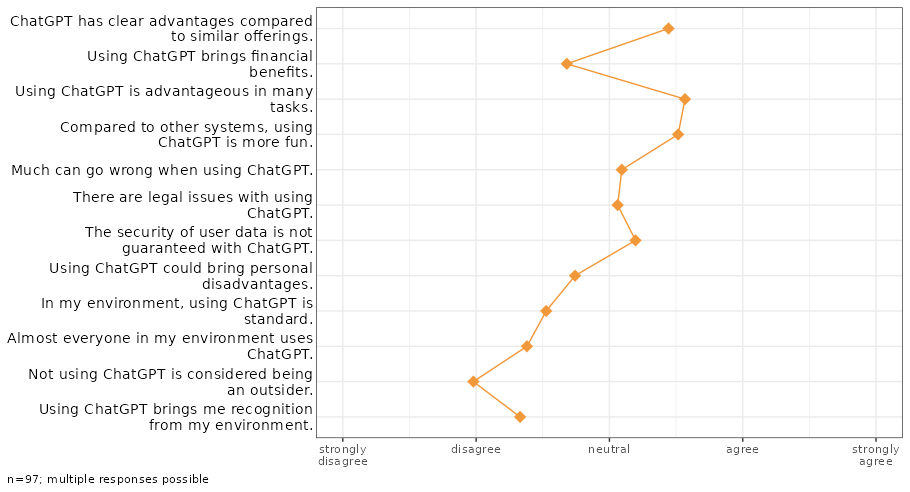

*4 missing case(s) omitted.*

###### Table

| Expectations | min | q1 | median | q3 | max | mean | sd | n |
| --- | --- | --- | --- | --- | --- | --- | --- | --- |
| ChatGPT has clear advantages compared to similar offerings. | 1 | 3 | 4 | 4 | 5 | 3.4 | 1.0 | 97 |
| Using ChatGPT brings financial benefits. | 1 | 2 | 3 | 4 | 5 | 2.7 | 1.2 | 97 |
| Using ChatGPT is advantageous in many tasks. | 1 | 3 | 4 | 4 | 5 | 3.6 | 1.1 | 97 |
| Compared to other systems, using ChatGPT is more fun. | 1 | 3 | 4 | 4 | 5 | 3.5 | 1.0 | 97 |
| Much can go wrong when using ChatGPT. | 1 | 2 | 3 | 4 | 5 | 3.1 | 1.1 | 97 |
| There are legal issues with using ChatGPT. | 1 | 2 | 3 | 4 | 5 | 3.1 | 1.2 | 97 |
| The security of user data is not guaranteed with ChatGPT. | 1 | 3 | 3 | 4 | 5 | 3.2 | 1.0 | 97 |
| Using ChatGPT could bring personal disadvantages. | 1 | 2 | 3 | 3 | 5 | 2.7 | 1.1 | 97 |
| In my environment, using ChatGPT is standard. | 1 | 2 | 2 | 3 | 5 | 2.5 | 1.1 | 97 |
| Almost everyone in my environment uses ChatGPT. | 1 | 1 | 2 | 3 | 5 | 2.4 | 1.2 | 97 |
| Not using ChatGPT is considered being an outsider. | 1 | 1 | 2 | 3 | 5 | 2.0 | 1.2 | 97 |
| Using ChatGPT brings me recognition from my environment. | 1 | 1 | 2 | 3 | 5 | 2.3 | 1.2 | 97 |

*n=97. 4 missing case(s) omitted.*

###### Index: Plot

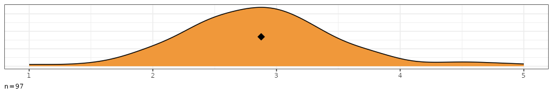

*4 missing case(s) omitted.*

###### Index: Table

| Index: cg_adoption | value |
| --- | --- |
| min | 1 |
| q1 | 2.4 |
| median | 2.8 |
| q3 | 3.2 |
| max | 5 |
| mean | 2.9 |
| sd | 0.6 |
| n | 97 |
| items | 12 |
| alpha | 0.81 |

*n=97. 4 missing case(s) omitted.*

You can add an index as a new column using `add_index()`. A new column is created with the average value of all selected columns for each case. Provide a custom name for the column using the `newcol` parameter. The `report_metrics()` function still outputs reliability values for the column.

**Add a single index**

```r
ds %>%
  add_index(starts_with("cg_adoption_"), newcol = "idx_cg_adoption") %>%
  report_metrics(idx_cg_adoption)
```

**Compare the index values by group**

```r
ds %>%
  add_index(starts_with("cg_adoption_"), newcol = "idx_cg_adoption") %>%
  report_metrics(idx_cg_adoption, adopter)
```

**Add multiple indizes and summarize them**

```r
ds %>%
  add_index(starts_with("cg_adoption_")) %>%
  add_index(starts_with("cg_adoption_advantage")) %>%
  add_index(starts_with("cg_adoption_fearofuse")) %>%
  add_index(starts_with("cg_adoption_social")) %>%
  tab_metrics(starts_with("idx_cg_adoption"))
```

To reverse items, provide a selection of columns to the `cols.reverse`-parameter of `add_index()`.

## Factor and cluster analysis

The easiest way to conduct factor analysis or cluster analyses is to use the respective parameters in the `report_metrics()` function.

```r
ds |>
  report_metrics(starts_with("cg_adoption"), factors = TRUE, clusters = TRUE)
```

Currently, cluster analysis is performed using kmeans and factor analysis is a principal component analysis. Setting the parameters to true, automatically generates scree plots and selects the number of factors or clusters. Alternatively, you can explicitly specify the numbers.

**Add factor or cluster analysis results to the original data**

If you want to work with the results, use `add_factors()` and `add_clusters()` respectively. For factor analysis, new columns prefixed with “fct_” are created to store the factor loadings based on the specified number of factors. For clustering, an additional column prefixed with “cls_” is added that assigns each observation to a cluster number.

```r
ds |>
  add_factors(starts_with("cg_adoption"), k = 3) |>
  select(starts_with("fct_"))
```

Once you have added factor or cluster columns to your data set, you can use them with the report functions:

```r
ds |>
  add_factors(starts_with("cg_adoption"), k = 3)  |>
  report_metrics(fct_cg_adoption_1, fct_cg_adoption_2, metric = TRUE)
```

```r
ds |>
  add_clusters(starts_with("cg_adoption"), k = 3) |>
  report_counts(sd_gender, cls_cg_adoption, prop = "cols")
```

After explicitly adding factor or cluster columns, you can inspect the analysis results using `factor_tab()`, `factor_plot()` or `cluster_tab()`, `cluster_plot()`.

```r
ds |>
  add_factors(starts_with("cg_adoption"), k = 3)  |>
  factor_tab(starts_with("fct_"))
```

**Automatically determine the number of factors or clusters**

To automatically determine the optimal number of factors or clusters based on diagnostics, set k = NULL.

```r
ds |>
  add_factors(starts_with("cg_adoption"), k = NULL) |>
  factor_tab(starts_with("fct_cg_adoption"))
```

## Modeling: Regression and Analysis of Variance

Modeling in the statistical sense is predicting an outcome (dependent variable) from one or multiple predictors (independent variables).

The report_metrics() function calculates a linear model if the model parameter is TRUE. You provide the variables in the following parameters:

- Dependent metric variable: first parameter after the dataset (cols parameter).
- Independent categorical variables: a tidy column selection in the second parameter (cross parameter).
- Independent metric variables: a tidy column selection in the third parameter (metric parameter.
- Interaction effects: interactions-parameter with a vector of multiplication terms (e.g. `interactions = c(sd_age * sd_gender)`)

```r
ds |>
 filter(sd_gender != "diverse") |>
 report_metrics(
   use_work,
   cross = c(sd_gender, adopter),
   metric = sd_age,
   model = TRUE,
   diagnostics = TRUE
 )
```

Four selected diagnostic plots are generated if the diagnostics-parameter is TRUE:

- Residual vs. fitted: Residuals should be evenly distributed vertically. Horizontally, they should follow the straight line. Otherwise this could be an indicator for heteroscedasticity, non-linearity or auto-correlationb.
- Scale-location plot: Points should be evenly distributed, without a pattern, as in the residual plot.
- Q-Q-Plot of fitted values: All dots should be located on a straight line. Otherweise, this may indicate non-linearity or that residuals are not normally distributed.
- Cooks’ distance plot: High values indicate that single cases influence the model disproportionally. Rule of thumb: Cook’s distance > 1 is a problem.

To work with the predicted values, use add_model() instead of the report function. This will add a new variable prefixed with `prd_` holding the target scores.

```r
ds <- ds |>
  add_model(
   use_work,
   categorical = c(sd_gender, adopter),
   metric = sd_age
 )

report_metrics(ds, use_work, prd_use_work, metric = T)
```

There are two functions to get the regression table or plot from the new column:

```r
model_tab(ds, prd_use_work)
model_plot(ds, prd_use_work)
```

By default, p values are adjusted to the number of tests by controlling the false discovery rate (fdr). Set the adjust-parameter to FALSE for disabling p correction.

### Reliability scores (and classification performance indicators)

In content analysis, reliability is usually checked by coding the cases with different persons and then calculating the overlap. To calculate reliability scores, prepare one data frame for each person:

- All column names in the different data frames should be identical.  
  Codings must be either binary (TRUE/FALSE) or contain a fixed number of values such as “sports”, “politics”, “weather”.
- Add a column holding initials or the name of the coder.
- One column must contain unique IDs for each case, e.g. a running case number.

Next, you row bind the data frames. The columns for coder and ID make sure that each coding is uniquely identified and can be related to the cases and coders.

```
data_coded <-  bind_rows(
  data_coder1,
  data_coder2
)
```

The final data, for example, looks like:

| case | coder | topic_sports | topic_weather |
| --- | --- | --- | --- |
| 1 | anne | TRUE | FALSE |
| 2 | anne | TRUE | FALSE |
| 3 | anne | FALSE | TRUE |
| 1 | ben | TRUE | TRUE |
| 2 | ben | TRUE | FALSE |
| 3 | ben | FALSE | TRUE |

Calculating reliability is straight forward with report_counts():

- Provide the data to the first parameter.
- Add the column with codings (or a selection of multiple columns, e.g. using `starts_with()`) to the second parameter.
- Set the the third parameter to the column name with coder names or initials.
- Set the ids-parameter to the column that contains case IDs or case numbers (this tells the volker-package which cases belong together).
- Set the agree-parameter to “reliability” to request reliability scores.

Example:

```
report_counts(data_coded, starts_with("topic_"), coder, ids = case, prop="cols", agree = "reliability")
```

Alternatively, if you are only interested in the scores, not a plot, you get them using agree_tab. Hint: You may abbreviate the reliability value.

```
agree_tab(data_coded, starts_with("topic_"), coder, ids = case, method="reli")
```

Further, you can request classification performance indicators (accuracy, precision, recall, F1) with the same function by setting the method to “classification” (may be abbreviated). Use this option if you compare manual codings to automated codings (classifiers, large language models). By default, you get macro statistics (average precision, recall and f1 over categories).

Give you have multiple values in on column, you may focus one category to get micro statistics:

```
agree_tab(starts_with("topic_"), coder, ids = case, method = "class", category = "catcontent")
```

## The mystery of missing values

Cases with missing values, by default, are omitted in all methods. Thus, the calculations are only based on cases with complete values in the selected columns.

Furthermore, each function first cleans the values:

- Residual levels defined in the `VLKR_NA_LEVELS` constant are recoded to missing values (“[NA] nicht beantwortet”, “[NA] keine Angabe”, “[no answer]” and “keine Angabe”).
- Residual numeric values defined in the `VLKR_NA_NUMBERS` constant are recoded to missing values (-9, -2, and -1).

```r
print(volker:::VLKR_NA_LEVELS)
```

```
#> [1] "[NA] nicht beantwortet" "[NA] keine Angabe"      "[no answer]"
#> [4] "keine Angabe"
```

```r
print(volker:::VLKR_NA_NUMBERS)
```

```
#> [1] -9 -2 -1
```

The output always contains information about how many cases were removed due to missing values. You have three options to treat missings:

1. Disable recoding by setting the `clean`-parameter of the functions to `FALSE`.
2. Override the values in VLKR_NA_LEVELS and VLKR_NA_NUMBERS by calls such as `options(vlkr.na.levels=c("Not answered"))` or `options(vlkr.na.numbers=c(-2,-9))`. If you set the value to `FALSE`, no values are recoded.
3. When analysing items, use pairwise complete data by calling `options(vlkr.na.omit=FALSE)` (maximal information from all items).

## What’s behind the scenes?

The volker-package is based on standard methods for data handling and visualisation. You could produce all outputs on your own. The package just makes your code dry - don’t repeat yourself - and wraps often used snippets into a simple interface.

Report functions call subsidiary tab, plot and effect functions, which in turn call functions specifically designed for the provided column selection. Open the package help to see, to which specific functions the report functions are redirected.

Console and markdown output is pimped by specific print- and knit-functions. To make this work, the cleaned data, produced plots, tables and markdown snippets gain new classes (`vlkr_df`, `vlkr_plt`, `vlkr_tbl`, `vlkr_list`, `vlkr_rprt`).

The volker-package makes use of common tidyverse functions. Basically, most outputs are generated by three functions:

- `count()` is used to produce counts
- `skim()` is used to produce metrics
- `ggplot()` is used to assemble plots.

Statistical tests, clustering and factor analysis are largely based on the stats, psych, car and effectsize packages.

Thanks to all the maintainers, authors and contributors of the packages that make the world of data a magical place.